# Sesion5_clusters

Jorge de la Vega

4/11/2021

# Ejemplos para seguir las notas.

En este laboratorio utilizaremos los datos de la ENIGH 2020 por eentidad federativa. Las variables que están disponibles son las siguientes. Todos los datos de dinero son trimestrales:

- `entidad`: Entidad de la República Mexicana.
- `edad`: Edad promedio del o de la jefa del hogar
- `poblacion`: total de hombres y mujeres adultas.
- `hombres`: número total de hombres
- `mujeres`: número total de mujeres
- `deudas`: pago promedio de deudas de los miembros del hogar a la empresa donde trabajan y/o a otras personas o instituciones.
- `salud`: gasto promedio en cuidados de salud
- `gasto`: gasto corriente monetario promedio
- `ingreso`: ingreso corriente promedio
- `beneficios`: ingreso por beneficios gubernamentales promedio
- `ahorro`: depósitos promedio en cuentas de ahorro, tandas, cajas de ahorro, etc.
- `pago_tarjeta`: pago promedio a tarjetas de crédito
- `bebidas`: gasto promedio en bebidas alcohólicas y no alcohólicas

```r
enigh20 <- read.csv("../data/Enigh20_1.csv")
# Pasa los nombres de las entidades como nombres de los renglones y quita la columna
row.names(enigh20) <- enigh20$entidad
enigh20$entidad <- NULL
```

Hacemos algunas transformaciones para simplificar los datos.

```r
enigh20$hombres <- round(100*enigh20$hombres/enigh20$poblacion,2)
enigh20$mujeres <- round(100*enigh20$mujeres/enigh20$poblacion,2)
enigh20$poblacion <- NULL # Quitamos población porque es redundante
```

Cuando los aributos tienen diferentes magnitudes, es recomendable estandarizar los datos.

```r
enigh20 <- scale(enigh20) #normaliza los datos (resta media y divide entre desviación estandar)
```

## Distancia y Similitud

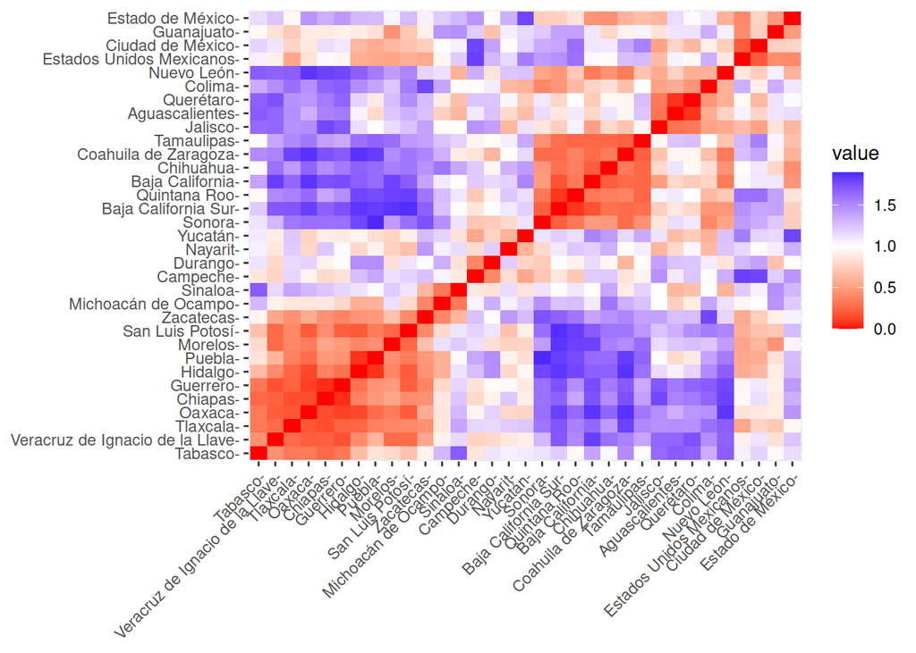

```r
# matriz de distancias euclideanas
d1 <- dist(enigh20)  # por default es euclideana
d2 <- dist(enigh20, method = "canberra")
d3 <- dist(enigh20, method = "minkowski")
# distancia basada en correlación
d4 <- get_dist(enigh20,method = "pearson")
# Podemos visualizar las distancias
fviz_dist(d4)
```

```r
# disimilaridad basada en la métrica de Gower
d5 <- daisy(enigh20, metric = "gower")
# Convierte distancia a similitud
c1 <- 10000/(1+d1)
c2 <- round((max(d1)-d1)/max(d1),2)
```

¿Qué estados son menos parecidos en función de las variables dadas? ¿Cuáles son los pares de ciudades más parecidos?

**Ejemplo de distancias en términos de atributos.**

Consideremos un ejercicio para ver la similitud por atributos. Consideremos la similitud de los estados en función de las letras que forman sus nombres.

```r
tieneletra <- function(x,letra){
  ifelse(length(which(unlist(strsplit(tolower(x),"")) ==letra))>0,1,0)
}
entidades <- row.names(enigh20)
nombres <- data.frame(a = sapply(entidades,tieneletra,letra = "a"),
                      b = sapply(entidades,tieneletra,letra = "b"),
                      e = sapply(entidades,tieneletra,letra = "e"),
                      i = sapply(entidades,tieneletra,letra = "i"),
                      o = sapply(entidades,tieneletra,letra = "o"),
                      u = sapply(entidades,tieneletra,letra = "u"))
dist(nombres, "binary")
```

```
##                                 Estados Unidos Mexicanos Aguascalientes
## Aguascalientes                                 0.2000000
## Baja California                                0.5000000      0.6666667
## Baja California Sur                            0.3333333      0.5000000
## Campeche                                       0.6000000      0.5000000
## Coahuila de Zaragoza                           0.0000000      0.2000000
## Colima                                         0.4000000      0.6000000
## Chiapas                                        0.6000000      0.5000000
## Chihuahua                                      0.4000000      0.2500000
## Ciudad de México                               0.0000000      0.2000000
## Durango                                        0.4000000      0.6000000
## Guanajuato                                     0.4000000      0.6000000
## Guerrero                                       0.4000000      0.6000000
## Hidalgo                                        0.4000000      0.6000000
## Jalisco                                        0.4000000      0.6000000
## Estado de México                               0.2000000      0.4000000
## Michoacán de Ocampo                            0.2000000      0.4000000
## Morelos                                        0.6000000      0.8000000
## Nayarit                                        0.6000000      0.5000000
## Nuevo León                                     0.4000000      0.6000000
## Oaxaca                                         0.6000000      0.8000000
## Puebla                                         0.5000000      0.4000000
## Querétaro                                      0.2000000      0.4000000
## Quintana Roo                                   0.2000000      0.4000000
## San Luis Potosí                                0.2000000      0.4000000
## Sinaloa                                        0.4000000      0.6000000
## Sonora                                         0.6000000      0.8000000
## Tabasco                                        0.6666667      0.8333333
## Tamaulipas                                     0.4000000      0.2500000
## Tlaxcala                                       0.8000000      0.7500000
## Veracruz de Ignacio de la Llave                0.0000000      0.2000000
## Yucatán                                        0.6000000      0.5000000
## Zacatecas                                      0.6000000      0.5000000
##                                 Baja California Baja California Sur  Campeche
## Aguascalientes
## Baja California
## Baja California Sur                   0.2000000
## Campeche                              0.8000000           0.8333333
## Coahuila de Zaragoza                  0.5000000           0.3333333 0.6000000
## Colima                                0.2500000           0.4000000 0.7500000
```

[output cut: 275 more lines]

```
## Nayarit
## Nuevo León
## Oaxaca
## Puebla
## Querétaro
## Quintana Roo
## San Luis Potosí
## Sinaloa
## Sonora
## Tabasco
## Tamaulipas
## Tlaxcala
## Veracruz de Ignacio de la Llave
## Yucatán                                               0.6000000
## Zacatecas                                             0.6000000 0.6666667
```

## Métodos de conglomerados jerárquicos

La función `agnes` realiza _agglomerative nesting: agrupa partiendo de cada caso hasta agrupar todo.

```r
# se realiza sobre los datos originales
agnes1 <- agnes(enigh20, metric = "euclidean", method = "single", diss = F)
agnes1$ac # agglomerative coefficient. cercano a 1 indica una mejor agrupación.
```

```
## [1] 0.4559771
```

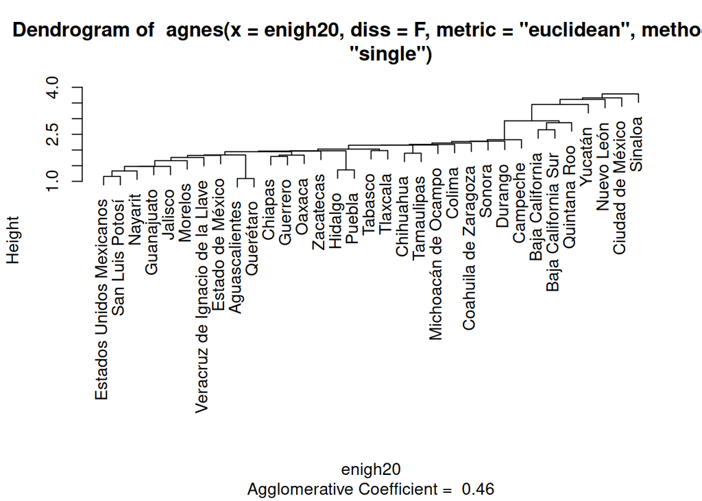

```r
plot(agnes1, which.plots = 2)
```

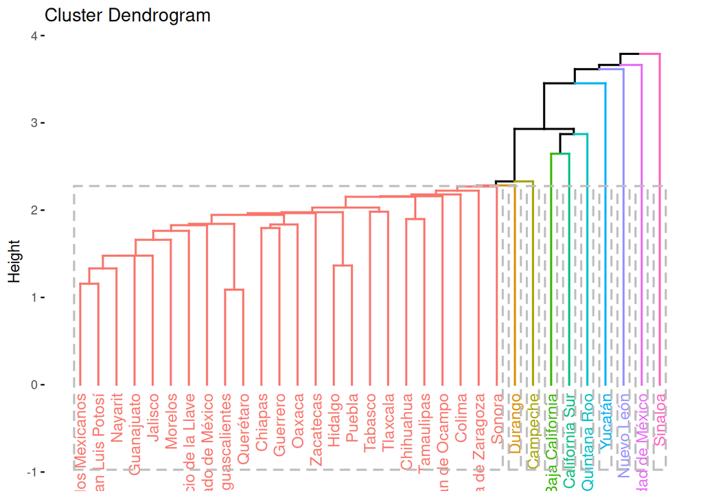

```r
fviz_dend(agnes1, k = 10, type = "rectangle", rect = T)  # define un número de grupos para cotar el dedrograma
```

```r
# Si se tiene la mtriz de distancias
agnes2 <- agnes(d2, method = "single", diss = T)
agnes2$ac
```

```
## [1] 0.3528467
```

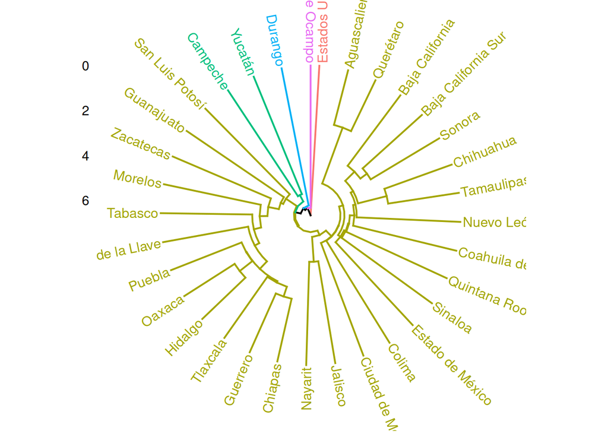

```r
fviz_dend(agnes2, k = 5, type = "circular")  # define un número de grupos para cortar el dendrograma
```

Otra función es `diana` que realiza *divised analysis* que es lo opuesto aagnes: parte del total hasta llegar a cada caso.

```r
diana1 <- diana(enigh20,metric = "euclidean", diss = F)
diana1$dc # coeficiente divisivo. Cercano a 1 e indicación de buena segmentación
```

```
## [1] 0.7245379
```

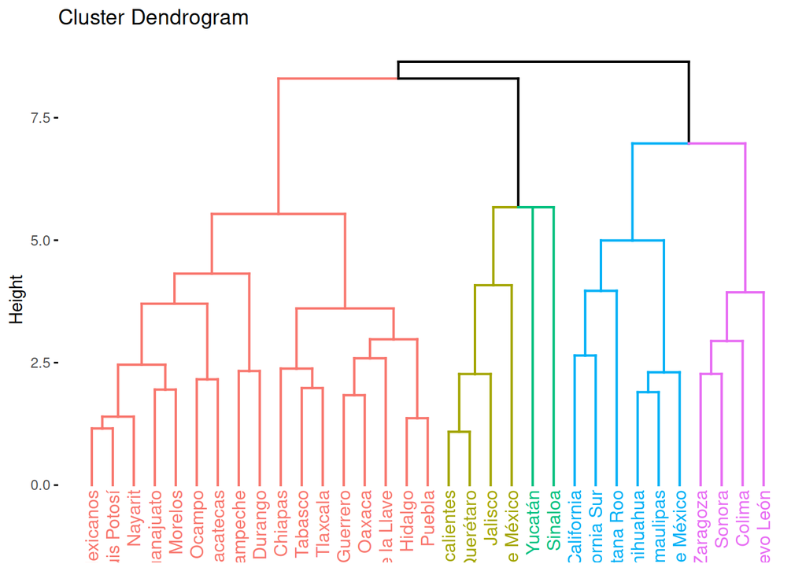

```r
fviz_dend(diana1,k = 5)
```

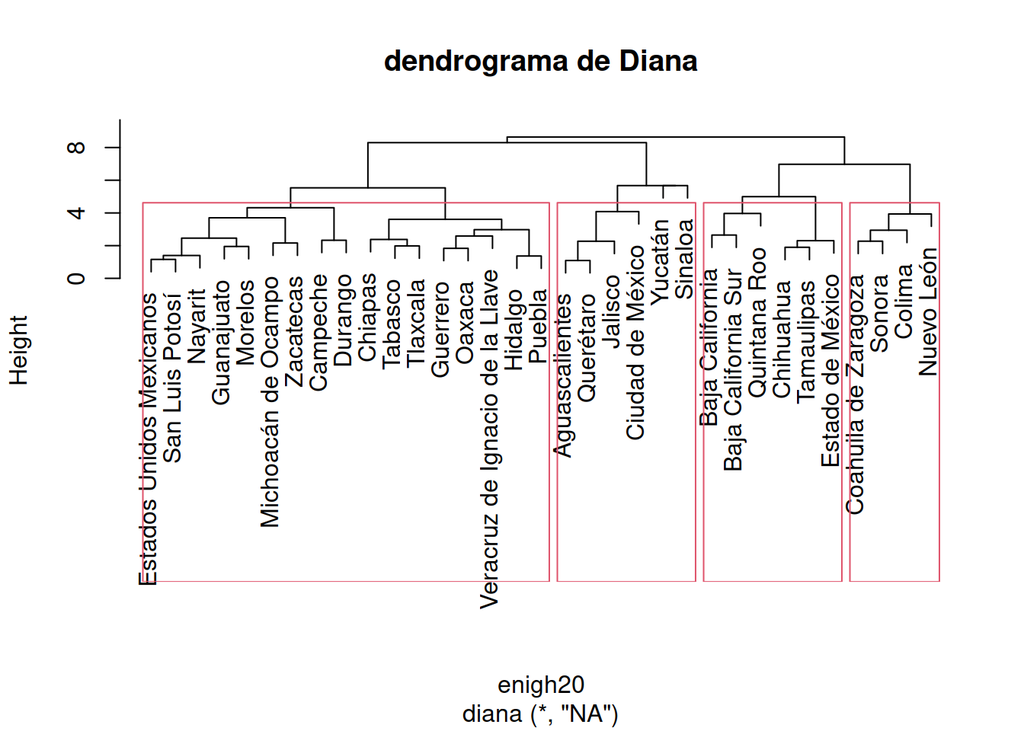

```r
# Otra gráfica alternativa
pltree(diana1, main = "dendrograma de Diana")
rect.hclust(diana1, k = 4)
```

```r
cutree(diana1,4) # devuelve vector de pertenencia
```

```
##  [1] 1 2 3 3 1 4 4 1 3 2 1 1 1 1 2 3 1 1 1 4 1 1 2 3 1 2 4 1 3 1 1 2 1
```

Otra función que hace cluter jeráŕquico es `hclust`. Esta funcion no pertenece a ningún paquete y forma parte de las funciones normales de R.

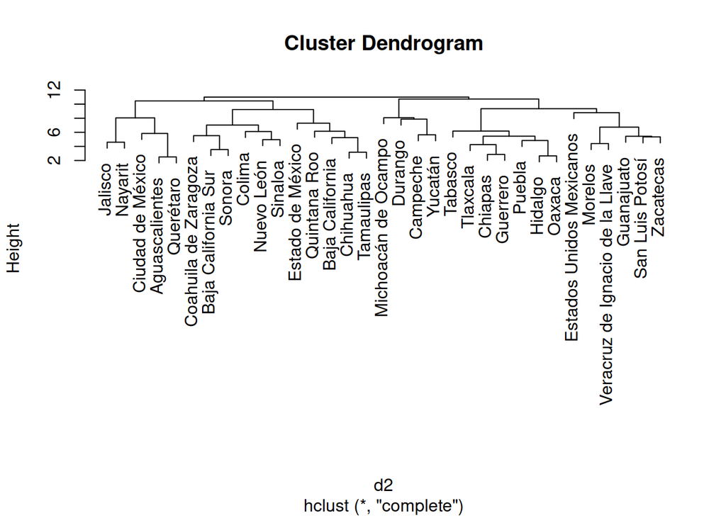

```r
h1 <- hclust(d2, method = "complete")
plot(h1)
```

```r
cutree(h1,4) # muestra los grupos.
```

```
##        Estados Unidos Mexicanos                  Aguascalientes
##                               1                               2
##                 Baja California             Baja California Sur
##                               3                               3
##                        Campeche            Coahuila de Zaragoza
##                               4                               3
##                          Colima                         Chiapas
##                               3                               1
##                       Chihuahua                Ciudad de México
##                               3                               2
##                         Durango                      Guanajuato
##                               4                               1
##                        Guerrero                         Hidalgo
##                               1                               1
##                         Jalisco                Estado de México
##                               2                               3
##             Michoacán de Ocampo                         Morelos
##                               4                               1
##                         Nayarit                      Nuevo León
##                               2                               3
##                          Oaxaca                          Puebla
##                               1                               1
##                       Querétaro                    Quintana Roo
##                               2                               3
##                 San Luis Potosí                         Sinaloa
##                               1                               3
##                          Sonora                         Tabasco
##                               3                               1
##                      Tamaulipas                        Tlaxcala
##                               3                               1
## Veracruz de Ignacio de la Llave                         Yucatán
##                               1                               4
##                       Zacatecas
##                               1
```

### Ejemplo: Posicionamiento de marca

Ejemplo de acuerdo a las notas. Los datos tienen los scores que califican 9 atributos de 10 marcas. Las calificaciones van de 1 a 10 para cada atributo de cada marca.

```r
ratings <- read.csv("../data/brands8.csv")
summary(ratings)
```

```
##     perform           leader           latest            fun
##  Min.   : 1.000   Min.   : 1.000   Min.   : 1.000   Min.   : 1.000
##  1st Qu.: 1.000   1st Qu.: 2.000   1st Qu.: 4.000   1st Qu.: 4.000
##  Median : 4.000   Median : 4.000   Median : 7.000   Median : 6.000
##  Mean   : 4.488   Mean   : 4.417   Mean   : 6.195   Mean   : 6.068
##  3rd Qu.: 7.000   3rd Qu.: 6.000   3rd Qu.: 9.000   3rd Qu.: 8.000
##  Max.   :10.000   Max.   :10.000   Max.   :10.000   Max.   :10.000
##     serious          bargain           value            trendy
##  Min.   : 1.000   Min.   : 1.000   Min.   : 1.000   Min.   : 1.00
##  1st Qu.: 2.000   1st Qu.: 2.000   1st Qu.: 2.000   1st Qu.: 3.00
##  Median : 4.000   Median : 4.000   Median : 4.000   Median : 5.00
##  Mean   : 4.323   Mean   : 4.259   Mean   : 4.337   Mean   : 5.22
##  3rd Qu.: 6.000   3rd Qu.: 6.000   3rd Qu.: 6.000   3rd Qu.: 7.00
##  Max.   :10.000   Max.   :10.000   Max.   :10.000   Max.   :10.00
##      rebuy           brand
##  Min.   : 1.000   Length:1000
##  1st Qu.: 1.000   Class :character
##  Median : 3.000   Mode  :character
##  Mean   : 3.727
##  3rd Qu.: 5.000
##  Max.   :10.000
```

En este caso no es necesario estandarizar los datos, pero se puede hacer de cualquier manera. Aquí se hará el análisis sin escalar los datos.

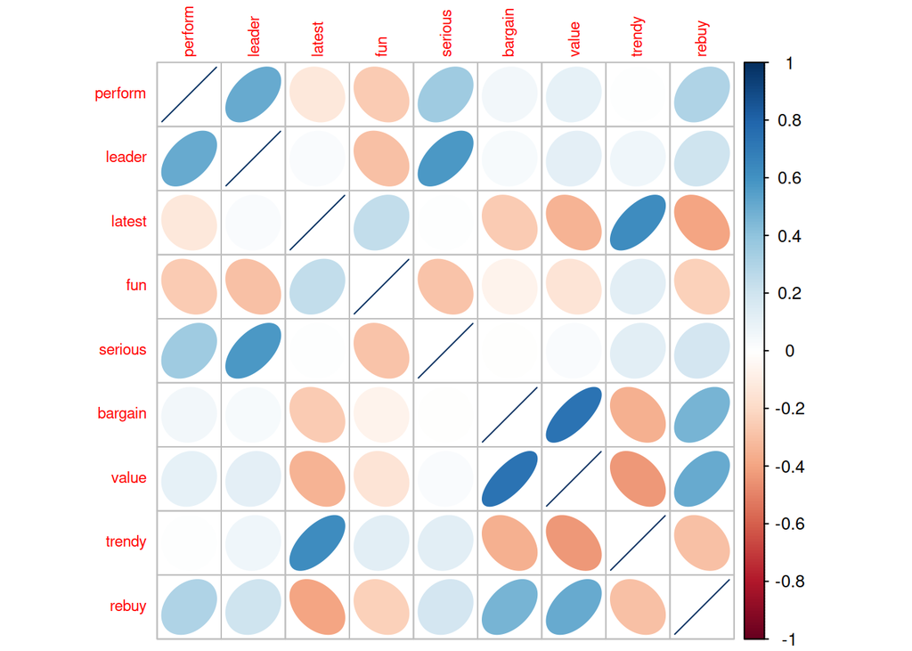

```r
corrplot(cor(ratings[,-10]), method = "ellipse", tl.cex= 0.7)
```

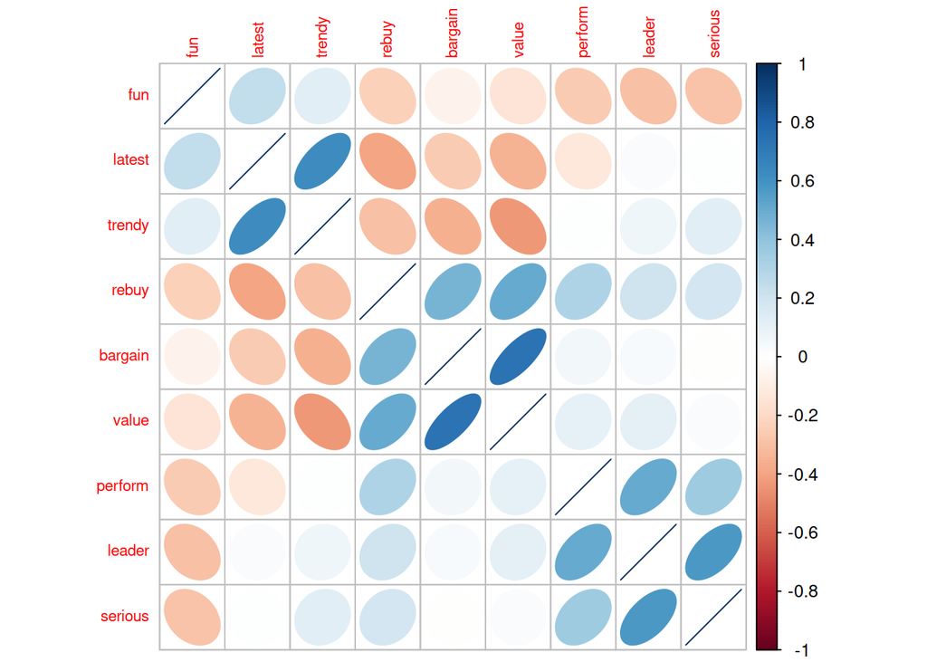

```r
corrplot(cor(ratings[,-10]), order = "hclust", method = "ellipse", tl.cex = 0.7)
```

Para poder ver el efecto de cada marca, obtenemos el rating promedio de los 100 clientes para cada una de ellas

```r
ratings_prom <- ratings %>%
                group_by(brand) %>%
                summarise_all(mean) %>%
                as.data.frame()
row.names(ratings_prom) <- ratings_prom$brand
ratings_prom$brand <- NULL
```

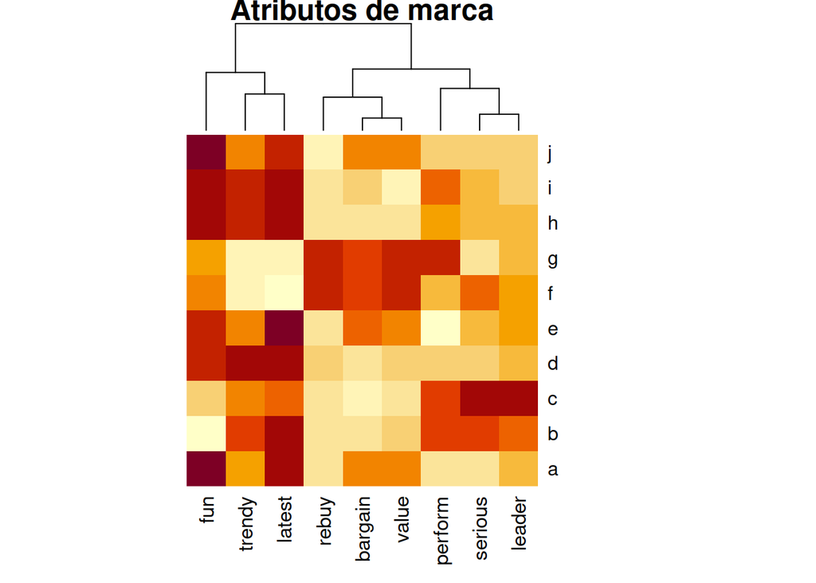

```r
heatmap(as.matrix(ratings_prom), Rowv = NA, main = "Atributos de marca")
```

Podemos intentar con los agregados hacer una gráfica de componentes principales para ver el posicionamiento de las marcas.

```r
ratings_prom_pc <- princomp(ratings_prom, cor = T)
summary(ratings_prom_pc, loadings = T)
```

```
## Importance of components:
##                          Comp.1    Comp.2     Comp.3     Comp.4    Comp.5
## Standard deviation     2.134521 1.7349473 0.76898915 0.61498280 0.5098261
## Proportion of Variance 0.506242 0.3344491 0.06570492 0.04202265 0.0288803
## Cumulative Proportion  0.506242 0.8406911 0.90639603 0.94841868 0.9772990
##                            Comp.6      Comp.7      Comp.8       Comp.9
## Standard deviation     0.36661576 0.215062433 0.145882355 0.0486674686
## Proportion of Variance 0.01493412 0.005139094 0.002364629 0.0002631692
## Cumulative Proportion  0.99223311 0.997372202 0.999736831 1.0000000000
##
## Loadings:
##         Comp.1 Comp.2 Comp.3 Comp.4 Comp.5 Comp.6 Comp.7 Comp.8 Comp.9
## perform  0.285  0.337  0.481  0.470  0.396  0.435
## leader   0.247  0.457 -0.317 -0.191         0.119 -0.610         0.451
## latest  -0.356  0.251 -0.496  0.275  0.461        -0.196 -0.119 -0.466
## fun     -0.336 -0.335 -0.152  0.324 -0.388  0.636 -0.246  0.179
## serious  0.212  0.475 -0.244 -0.212 -0.394  0.334  0.439        -0.407
## bargain  0.361 -0.278 -0.459  0.291  0.112  0.127  0.319 -0.513  0.321
## value    0.401 -0.241 -0.336         0.206                0.778
## trendy  -0.311  0.375         0.484 -0.273 -0.339  0.322  0.243  0.410
## rebuy    0.430                0.442 -0.438 -0.368 -0.352 -0.142 -0.372
```

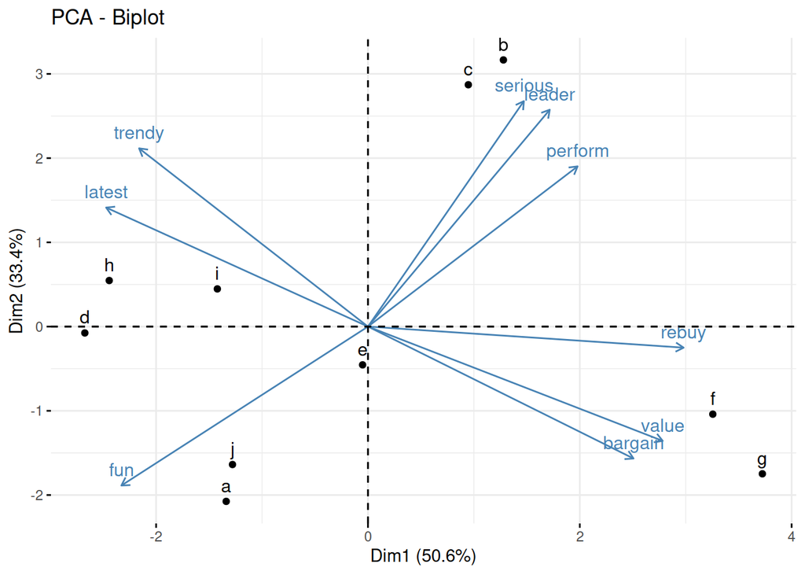

```r
fviz_pca(ratings_prom_pc)
```

## Conglmerados no jerárquicos

### K-medias

Hay varios algoritmos que desarrollan k-medias. Es importante fijar una semilla aleatoria inicial, porque la elección de los centros iniciales es aleatoria.

Primero determinamos cuántos clusters pueden ser óptimos:

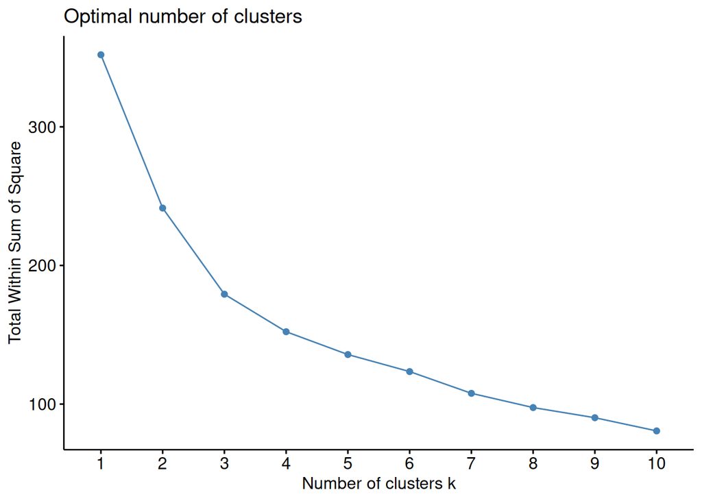

```r
fviz_nbclust(enigh20,kmeans, method = "wss")
```

`nstart` indica cuántos conjuntos aleatorios deben tomarse, cuando se provee un número de centros (clusters). Esto significa que se intentarán `nstart` diferentes asignaciones iniciales y se seleccionan los mejores resultados

```r
set.seed(10) # fija la semilla por reproducibilidad
km1 <- kmeans(enigh20,centers = 4, nstart = 50)
km1
```

```
## K-means clustering with 4 clusters of sizes 8, 11, 7, 7
##
## Cluster means:
##    edad_jefe    hombres    mujeres       gasto    ingreso     deudas
## 1  0.1397756 -0.8099458  0.8099458 -1.34102317 -1.2651281 -0.6239418
## 2  0.3358866 -0.1175866  0.1175866  0.03533589 -0.1340409  0.2003918
## 3  0.3577526 -0.3521914  0.3521914  1.03763388  0.9120339  0.5672658
## 4 -1.0453179  1.4626228 -1.4626228  0.43943620  0.7444625 -0.1690909
##          salud  beneficios     ahorro pago_tarjeta     bebida
## 1 -0.197635403  1.10974836 -0.8477849   -0.9915618 -1.2650429
## 2  0.007635534  0.01208173  0.2202280   -0.3133587 -0.1282713
## 3  1.035599782 -0.24518393  1.1293405    1.5152428  0.6623774
## 4 -0.821729446 -1.04208548 -0.5065160    0.1103915  0.9849551
##
## Clustering vector:
##        Estados Unidos Mexicanos                  Aguascalientes
##                               2                               3
##                 Baja California             Baja California Sur
##                               4                               4
##                        Campeche            Coahuila de Zaragoza
##                               2                               4
##                          Colima                         Chiapas
##                               3                               1
##                       Chihuahua                Ciudad de México
##                               4                               3
##                         Durango                      Guanajuato
##                               2                               2
##                        Guerrero                         Hidalgo
##                               1                               1
##                         Jalisco                Estado de México
##                               2                               2
##             Michoacán de Ocampo                         Morelos
##                               2                               2
##                         Nayarit                      Nuevo León
##                               2                               3
##                          Oaxaca                          Puebla
##                               1                               1
##                       Querétaro                    Quintana Roo
##                               3                               4
##                 San Luis Potosí                         Sinaloa
##                               2                               3
##                          Sonora                         Tabasco
##                               4                               1
##                      Tamaulipas                        Tlaxcala
##                               4                               1
## Veracruz de Ignacio de la Llave                         Yucatán
##                               1                               3
##                       Zacatecas
##                               2
##
## Within cluster sum of squares by cluster:
## [1] 24.11048 42.17494 51.78817 34.11651
##  (between_SS / total_SS =  56.8 %)
##
## Available components:
##
## [1] "cluster"      "centers"      "totss"        "withinss"     "tot.withinss"
## [6] "betweenss"    "size"         "iter"         "ifault"
```

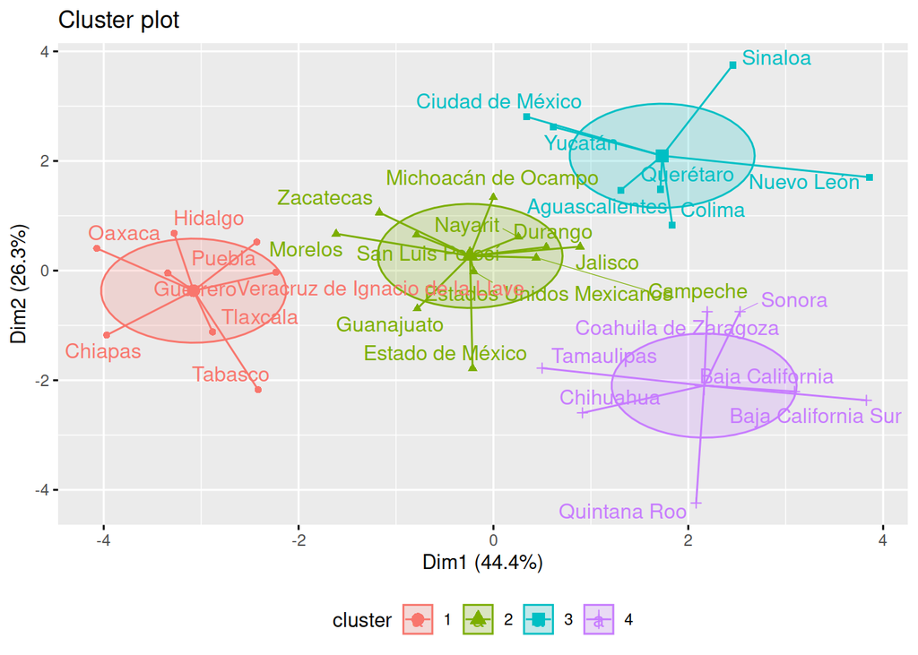

```r
fviz_cluster(km1,
             data = enigh20,
             ellipse.type = "euclid",
             star.plot = T,
             repel = T,
             ggtheme = theme(legend.position = "bottom"))
```

¿Es sensible al orden de los datos? podría ser que sí:

```r
e2 <- enigh20[sample(1:33,33,replace = F),]
set.seed(10) # fija la semilla por reproducibilidad
km1 <- kmeans(e2,centers = 4, nstart = 50)
km1
```

```
## K-means clustering with 4 clusters of sizes 7, 7, 11, 8
##
## Cluster means:
##    edad_jefe    hombres    mujeres       gasto    ingreso     deudas
## 1  0.3577526 -0.3521914  0.3521914  1.03763388  0.9120339  0.5672658
## 2 -1.0453179  1.4626228 -1.4626228  0.43943620  0.7444625 -0.1690909
## 3  0.3358866 -0.1175866  0.1175866  0.03533589 -0.1340409  0.2003918
## 4  0.1397756 -0.8099458  0.8099458 -1.34102317 -1.2651281 -0.6239418
##          salud  beneficios     ahorro pago_tarjeta     bebida
## 1  1.035599782 -0.24518393  1.1293405    1.5152428  0.6623774
## 2 -0.821729446 -1.04208548 -0.5065160    0.1103915  0.9849551
## 3  0.007635534  0.01208173  0.2202280   -0.3133587 -0.1282713
## 4 -0.197635403  1.10974836 -0.8477849   -0.9915618 -1.2650429
##
## Clustering vector:
##                         Hidalgo                        Guerrero
##                               4                               4
##                         Durango                          Puebla
##                               3                               4
##        Estados Unidos Mexicanos                         Tabasco
##                               3                               4
##                         Nayarit                          Colima
##                               3                               1
##             Baja California Sur                      Nuevo León
##                               2                               1
##                       Zacatecas                  Aguascalientes
##                               3                               1
##                Estado de México                         Jalisco
##                               3                               3
##                          Oaxaca                       Querétaro
##                               4                               1
##                          Sonora Veracruz de Ignacio de la Llave
##                               2                               4
##                 San Luis Potosí             Michoacán de Ocampo
##                               3                               3
##                Ciudad de México                       Chihuahua
##                               1                               2
##                      Guanajuato                         Chiapas
##                               3                               4
##                      Tamaulipas                        Tlaxcala
##                               2                               4
##                        Campeche                 Baja California
##                               3                               2
##                    Quintana Roo                         Yucatán
##                               2                               1
##            Coahuila de Zaragoza                         Morelos
##                               2                               3
##                         Sinaloa
##                               1
##
## Within cluster sum of squares by cluster:
## [1] 51.78817 34.11651 42.17494 24.11048
##  (between_SS / total_SS =  56.8 %)
##
## Available components:
##
## [1] "cluster"      "centers"      "totss"        "withinss"     "tot.withinss"
## [6] "betweenss"    "size"         "iter"         "ifault"
```

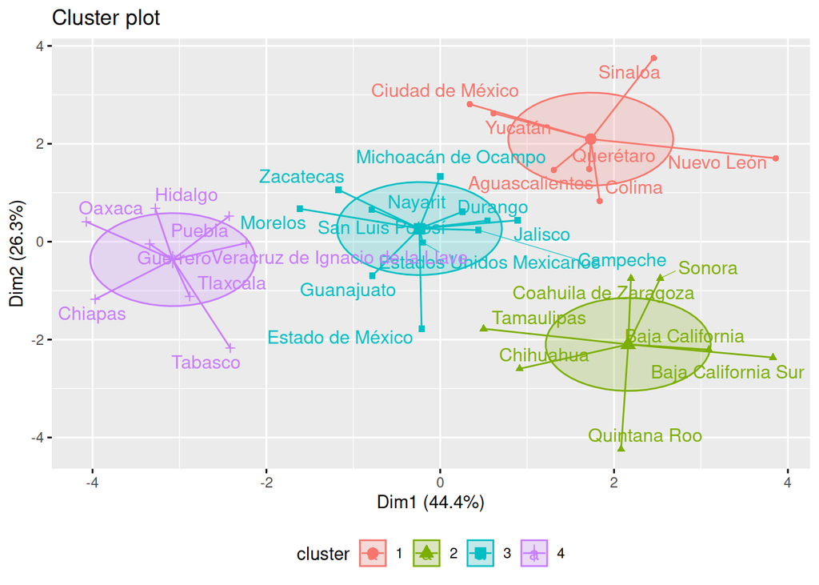

```r
fviz_cluster(km1,
             data = e2,
             ellipse.type = "euclid",
             star.plot = T,
             repel = T,
             ggtheme = theme(legend.position = "bottom"))
```